# Initial population sizes

# 1 Preamble

This is an Electronic Supplement to the manuscript Marques et al. “Quantifying Deepwater Horizon oil spill induced injury on pelagic cetaceans”.

The master file containing links to all supplementary files related to this paper is this Electronic Supplements master file.

If you make use of any of this material in your work, it would be appreciated if you would contact Tiago Marques to let him know.

# 2 Introduction

In this document we present the distribution for the initial population sizes, population exposed and proportion exposed for each of the stocks considered in the pelagic paper.

These population sizes were obtained from the models of

Roberts, J. J.; Best, B. D.; Mannocci, L.; Fujioka, E.; Halpin, P. N.; Palka, D. L.; Garrison, L. P.; Mullin, K. D.; Cole, T. V. N.; Khan, C. B.; McLellan, W. A.; Pabst, D. A. & Lockhart, G. G. 2016 Habitat-based cetacean density models for the U.S. Atlantic and Gulf of Mexico *Scientific Reports* **6**: 22615 DOI: [10.1038/srep22615](https://www.nature.com/articles/srep22615)

To obtain the number of animals exposed to oil (and hence the proportion of the population exposed to oil) the estimated fraction of the population based on the density surfaces that was contained in the area considered to be affected by oil was quantified. Said area is shown in the image below

[figure not shown]

```r
include_graphics(path = "figs/Figure1.JPG")
```

The taxonomic units considered and the corresponding codes are:

- Bwsp beaked whales Beaked whales spp
- Fatt pygmy killer whale *Feresa attenuata*
- Ggri Risso’s dolphin *Grampus griseus*
- Gmac short-finned pilot whale *Globicephala macrorhynchus*
- Kosp kogia *Kogia* sp.
- Pele melon-headed whale *Peponocephala electra*
- Pmac sperm whale *Physeter macrocephalus*
- Satt pantropical spotted dolphin *Stenella attenuata*
- Sbre rough-toothed dolphin *Steno bredanensis*
- Scly Clymene dolphin *Stenella clymene*
- Scoe striped dolphin *Stenella coeruleoalba*
- Sfro Atlantic spotted dolphin *Stenella frontalis*
- Slon spinner dolphin *Stenella longirostris*
- Ttro offshore bottlenose dolphins *Tursiops truncatus*
- Ttrs shelf bottlenose dolphins *Tursiops truncatus*

# 3 Population sizes

We begin by presenting a non-spatial perspective of the data, since that is simpler and our population dynamics model itself is intrinsically non-spatial, but we also present abundance over space, since that is what underlies the numbers we use, in particular since we need to overlay over space the oil footprint and the animal density surface.

The objects containing realizations of population size, both for the total abundance as well as the proportion of animals exposed to oil, are in 2 separate objects:

To present a spatial perspective of the abundances we require 2 shapefiles common to all pelagic taxonomic units:

- `OilCoverage.shp` - the oil coverage / footprint (in the folder `InputFiles`)
- `Study_Area_GOM_10km_Polygon` - the study area in 10 km grid cells (in the folder `InputFiles`)

and a couple of files per pelagic taxonomic unit:

- `N_bycell.csv` - the point estimate of the number of animals per grid cell, where grid cells are defined in `Study_Area_GOM_10km_Polygon`;
- `Prediction_Area.img` - the prediction area for each species

All the taxonomic units specific files are in the folder `InOutBySp`, stored under a sub-folder corresponding to each taxonomic unit.

The code to create all the above objects, as well as the actual density surface models from Roberts et al. 2016 over which they are based upon are not shared, since they are not ours to share. In that sense these should be taken as data.

We can plot these abundance distributions and density estimates over spece in turn for each taxonomic unit.

In the following we produce a plot for the initial population versus the exposed population and for the initial population versus the proportion exposed for each of the stocks considered. We also output the (usually 0 or very small) number of bootstrap resamples that were removed from further analysis for each species because they represented unrealistically large population sizes. These unrealistic realizations were created due to correspondingly unrealistic GAM extrapolations in the limits of the study area.

```r
#Define paths and filenames
supp.data.path <- "InputFiles/shapefiles"
#Read in oil coverage polygon
oil.coverage <- readOGR(supp.data.path, "OilCoverage")
```

```
## [1] "The following pairs of plots are for Bwsp"
## [1] "We removed 3 observation(s) that were considered GAM extrapolations gone bad"
```

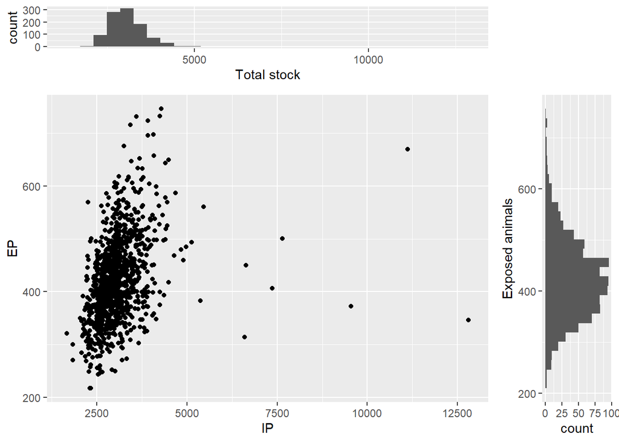

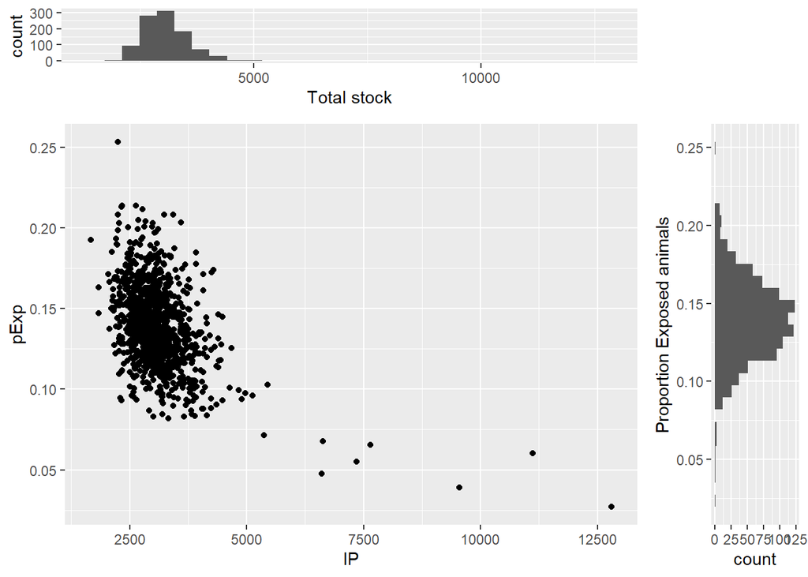

```
## [1] "The spatial distribution for Bwsp"
```

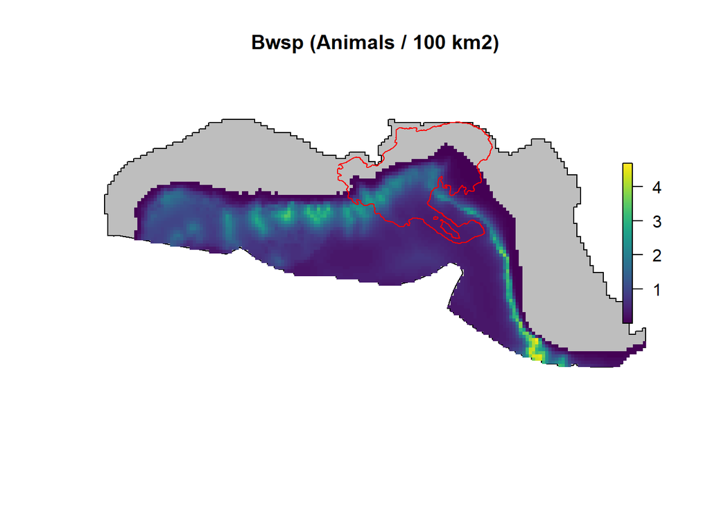

```
## [1] "The following pairs of plots are for Fatt"
## [1] "We removed 0 observation(s) that were considered GAM extrapolations gone bad"
```

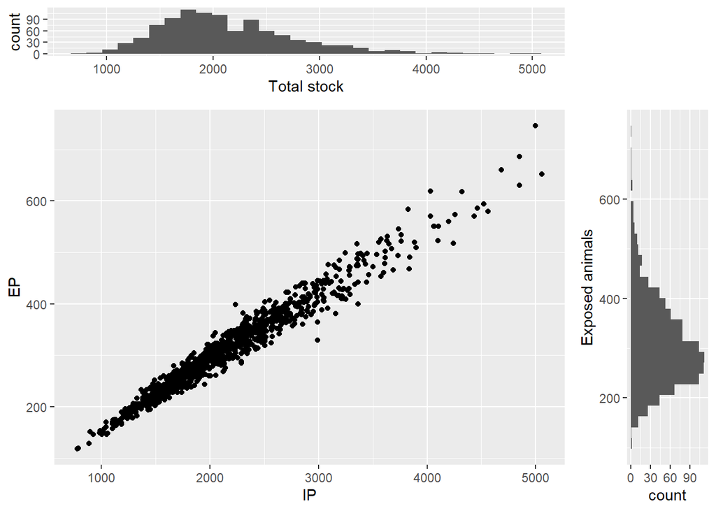

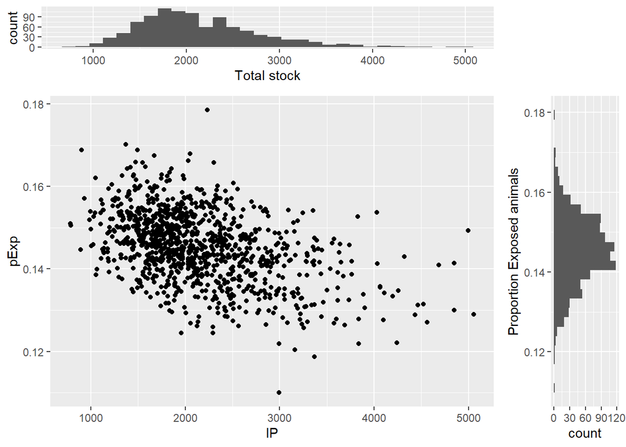

```
## [1] "The spatial distribution for Fatt"
```

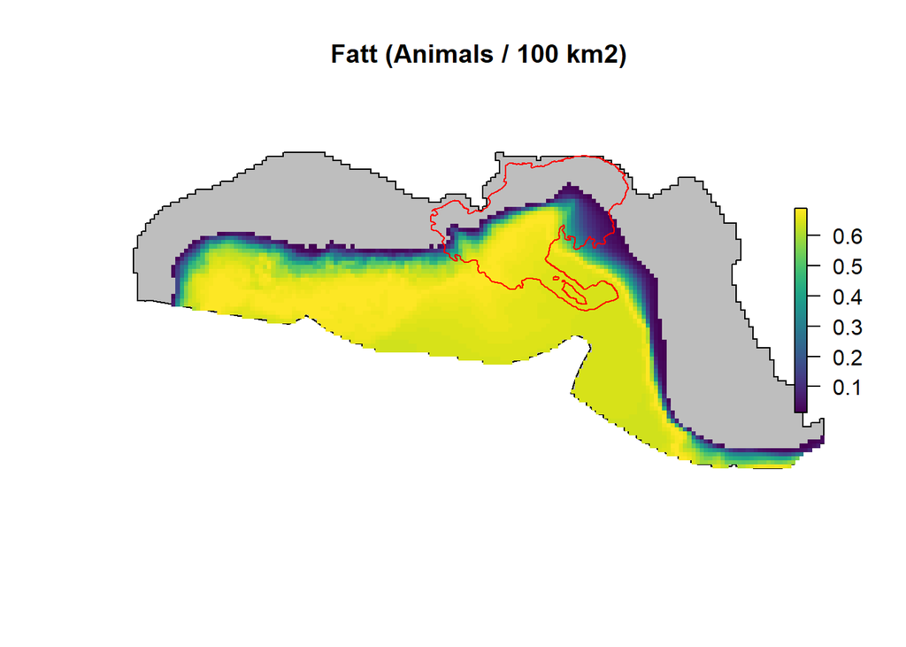

```
## [1] "The following pairs of plots are for Gmac"
## [1] "We removed 0 observation(s) that were considered GAM extrapolations gone bad"
```

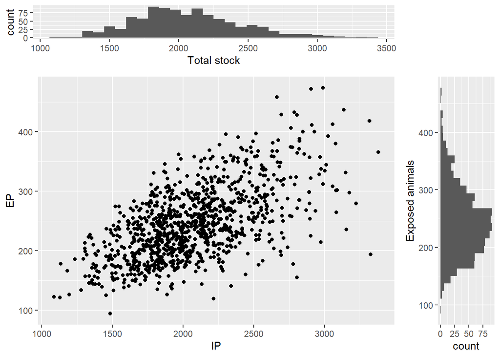

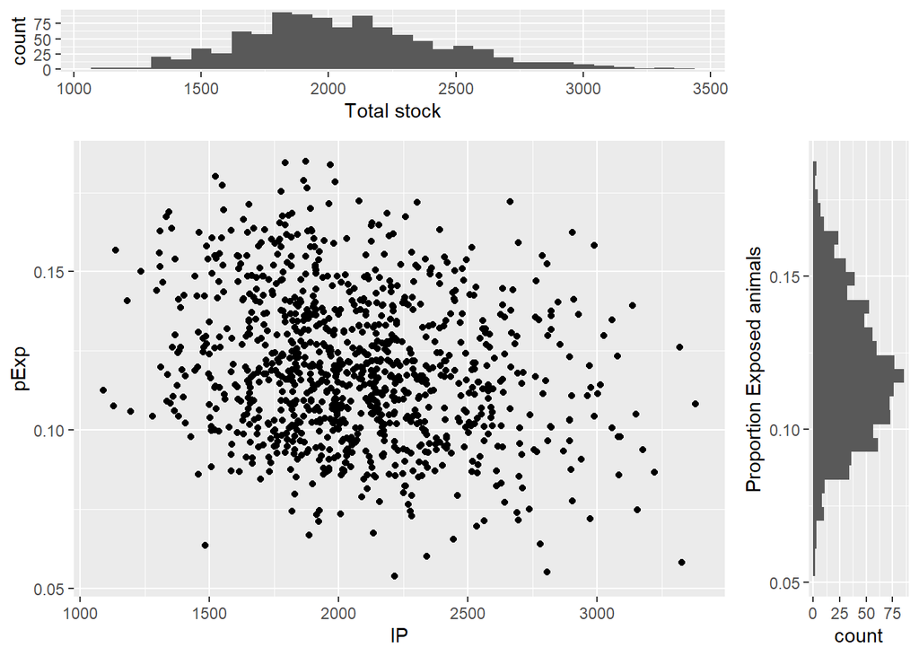

```
## [1] "The spatial distribution for Gmac"
```

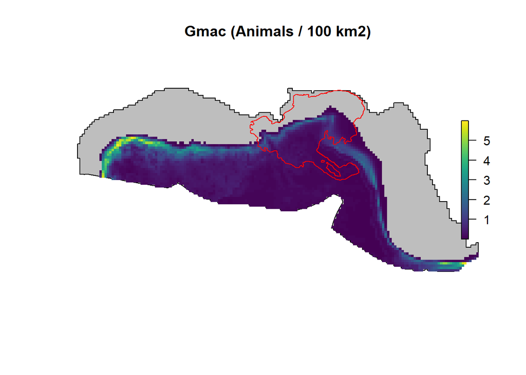

```
## [1] "The following pairs of plots are for Ggri"
## [1] "We removed 0 observation(s) that were considered GAM extrapolations gone bad"
```

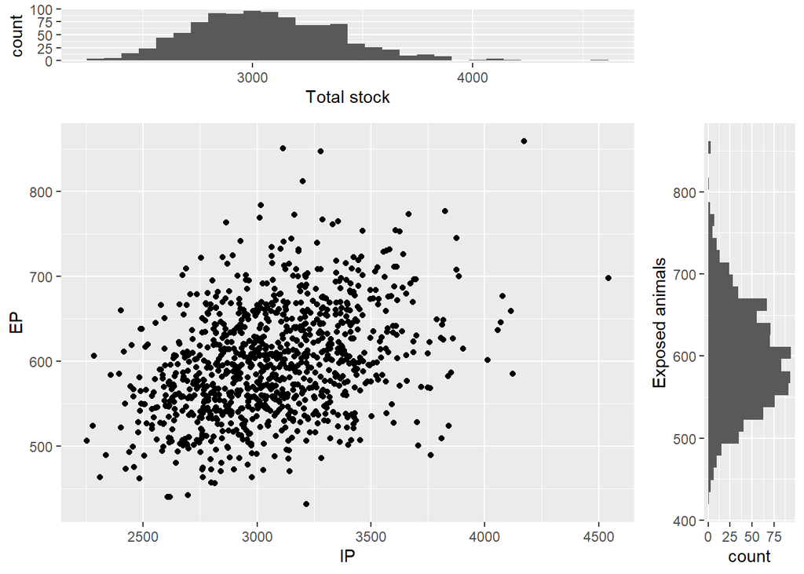

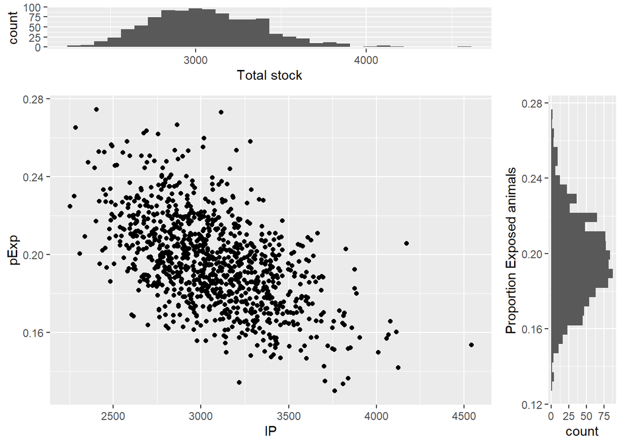

```
## [1] "The spatial distribution for Ggri"
```

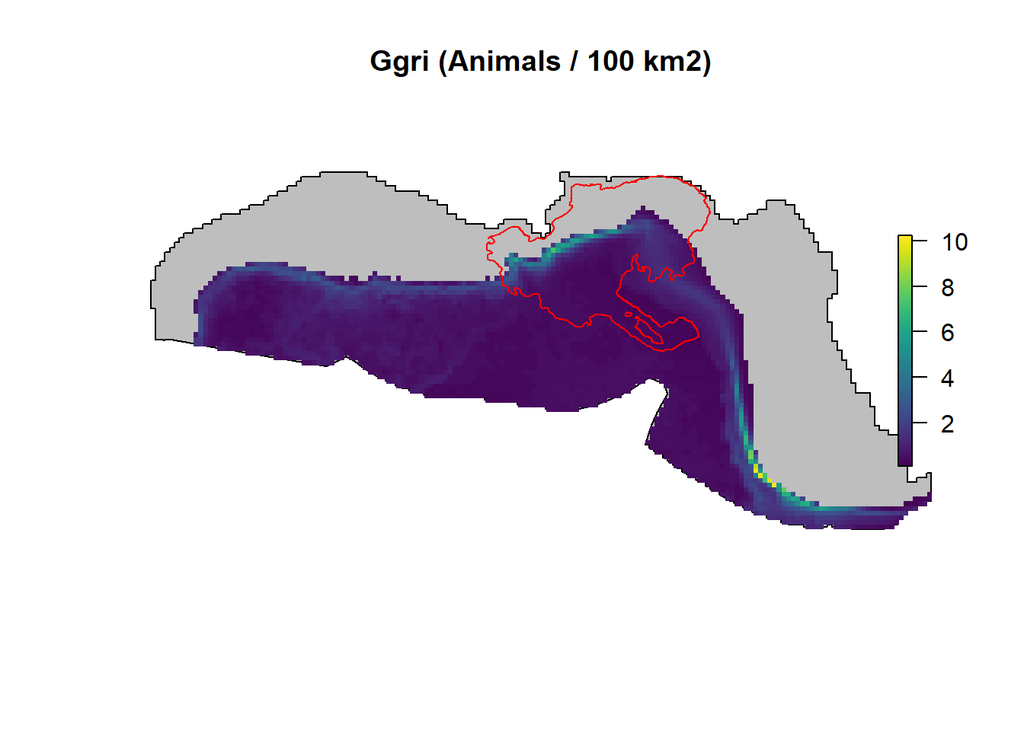

```
## [1] "The following pairs of plots are for Kosp"
## [1] "We removed 1 observation(s) that were considered GAM extrapolations gone bad"
```

[33 more figures not shown]

```r
#Read in study area polygon for later plotting
study.area <- readOGR(supp.data.path, "Study_Area_GOM_10km_Polygon")
```

A summary table, with the estimated mean for the initial population size (N), the exposed population size (Ne) and the proportion exposed (Pe) for each of the stocks considered. The sufix cv, L and U stand for the empirical Coefficient of Variation and Lower and Upper confidence interval bounds. These intervals were obtained by the quantile method.

| Sp | NL | N | NU | Ncv | NeL | Ne | NeU | Necv | PeL | Pe | PeU | Pecv |
| --- | --- | --- | --- | --- | --- | --- | --- | --- | --- | --- | --- | --- |
| Bwsp | 2236 | 3098 | 4323 | 23.2 | 286 | 424 | 604 | 19.1 | 0.093 | 0.140 | 0.191 | 18.5 |
| Fatt | 1137 | 2152 | 3762 | 31.1 | 170 | 310 | 520 | 28.6 | 0.128 | 0.145 | 0.161 | 5.9 |
| Gmac | 1378 | 2065 | 2910 | 18.7 | 146 | 245 | 374 | 24.2 | 0.077 | 0.120 | 0.165 | 19.3 |
| Ggri | 2489 | 3063 | 3759 | 10.6 | 486 | 598 | 730 | 10.8 | 0.154 | 0.197 | 0.248 | 11.9 |
| Kosp | 1650 | 2322 | 3288 | 18.1 | 312 | 458 | 687 | 20.3 | 0.166 | 0.197 | 0.240 | 9.7 |
| Pele | 3483 | 5784 | 9074 | 25.5 | 531 | 879 | 1363 | 24.8 | 0.138 | 0.152 | 0.166 | 4.8 |
| Pmac | 2117 | 2561 | 3094 | 9.5 | 396 | 489 | 595 | 10.3 | 0.168 | 0.191 | 0.216 | 6.4 |
| Satt | 72954 | 81233 | 90464 | 5.5 | 10875 | 12589 | 14353 | 6.9 | 0.142 | 0.155 | 0.168 | 4.2 |
| Sbre | 3271 | 4867 | 6804 | 19.0 | 491 | 720 | 1005 | 18.5 | 0.140 | 0.148 | 0.152 | 2.2 |
| Scly | 6873 | 9065 | 11826 | 14.1 | 474 | 737 | 1087 | 20.4 | 0.054 | 0.082 | 0.113 | 18.6 |
| Scoe | 3579 | 5011 | 6751 | 16.5 | 907 | 1219 | 1588 | 14.6 | 0.174 | 0.247 | 0.323 | 16.0 |
| Sfro | 37527 | 48688 | 62825 | 13.7 | 2150 | 2763 | 3501 | 12.0 | 0.041 | 0.058 | 0.078 | 16.4 |
| Slon | 9589 | 16501 | 27477 | 27.9 | 3411 | 6090 | 10430 | 29.8 | 0.217 | 0.377 | 0.555 | 22.5 |
| Ttro | 13705 | 15791 | 18445 | 7.6 | 2867 | 3232 | 3633 | 6.1 | 0.173 | 0.206 | 0.239 | 7.8 |
| Ttrs | 56992 | 64897 | 73804 | 6.6 | 9943 | 11466 | 13195 | 7.2 | 0.159 | 0.177 | 0.195 | 5.4 |

A quick check to see how many iterations were above the limit considered to be unrealistic and caused by GAM extrapolations and hence were removed from the analysis

| Sp | limit | above.limit |
| --- | --- | --- |
| Bwsp | 13210 | 3 |
| Fatt | 5494 | 0 |
| Gmac | 3997 | 0 |
| Ggri | 4684 | 0 |
| Kosp | 4468 | 1 |
| Pele | 13166 | 0 |
| Pmac | 3779 | 0 |
| Satt | 103746 | 0 |
| Sbre | 9486 | 0 |
| Scly | 15565 | 1 |
| Scoe | 9237 | 1 |
| Sfro | 81942 | 0 |
| Slon | 40384 | 2 |
| Ttro | 21756 | 0 |
| Ttrs | 86434 | 0 |

# 4 Producing values for tables in the paper

Producing the values that are used in table 1 of the paper

## 4.1 Table 1

```r
Table1 <-  paste0(round(sumNsPes$N,0),"; ",round(sumNsPes$Ncv,1)," (",round(sumNsPes$NL,0)," ,",round(sumNsPes$NU),")")
#note we remove the last row which has the Ttru for Barataria Bay
write.table(Table1[-length(Sps)],"Table1.txt",sep="\t",row.names = FALSE,quote = FALSE,col.names = FALSE)
```

## 4.2 Table 2

```r
Table2 <-  paste0(round(sumNsPes$Pe,3),"; ",round(sumNsPes$Pecv,1)," (",round(sumNsPes$PeL,3)," ,",round(sumNsPes$PeU,3),")")
#note we remove the last row which has the Ttru for Barataria Bay
write.table(Table2[-length(Sps)],"Table2.txt",sep="\t",row.names = FALSE,quote = FALSE,col.names = FALSE)
```

# 5 Producing tables used as input in Electronic Supplements

## 5.1 For “GetInjury.Rmd”

```r
write.table(sumNsPes,"Table4GetInjury.txt",sep="\t",row.names = FALSE,quote = FALSE,col.names = TRUE)
```

# 6 References

Roberts, J. J.; Best, B. D.; Mannocci, L.; Fujioka, E.; Halpin, P. N.; Palka, D. L.; Garrison, L. P.; Mullin, K. D.; Cole, T. V. N.; Khan, C. B.; McLellan, W. A.; Pabst, D. A. & Lockhart, G. G. 2016 Habitat-based cetacean density models for the U.S. Atlantic and Gulf of Mexico *Scientific Reports* **6**: 22615 DOI: [10.1038/srep22615](https://www.nature.com/articles/srep22615)